# Ray Unit 0 - Actors

Ray **actors** handle cluster-wide **state**: mutable data that persists across calls.

## Setup

Use the `22971-ray` environment and kernel.

```python
import time
import ray
import random
```

```python
ray.shutdown()
ray.init()
```

```
2026-04-24 08:01:01,534	INFO worker.py:2004 -- Started a local Ray instance. View the dashboard at http://127.0.0.1:8265
```

| **Python version:** | **3.12.13** |
| --- | --- |
| **Ray version:** | **2.54.0** |
| **Dashboard:** | **http://127.0.0.1:8265** |

## 1. Define an actor

Actors are long-lived **class instances**:

- persist across calls while their references/owner keep them alive, subject to failures and explicit termination
- maintain mutable state

Define the class:

```python
@ray.remote
class Counter:
    def __init__(self):
        self.value = 0

    def increment(self):
        self.value += 1
        return self.value

    def get_value(self):
        return self.value
```

Create a class instance (actor):

```python
counter = Counter.remote()

print(counter)
print(type(counter))
```

```
Actor(Counter, f0a5895891b9b7496ef716fc01000000)
<class 'ray.actor.ActorHandle'>
```

- `.remote()` submits construction somewhere in the cluster.
- It returns a **handle** immediately; the handle does not prove `__init__` finished.
- Method calls queue until construction completes.

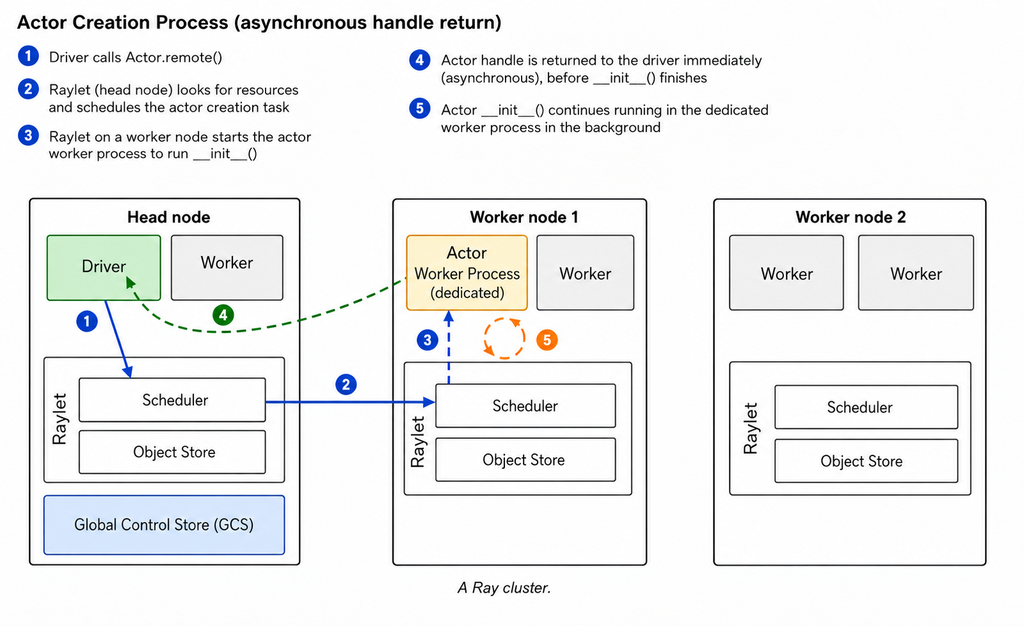

## 2. Call actor methods

Actor methods are invoked with `.remote(...)`, just like task calls.

The method call returns an `ObjectRef`. Use `ray.get(...)` to retrieve the actual result.

```python
val_ref1 = counter.get_value.remote()
print(val_ref1)
print(ray.get(val_ref1))

counter.increment.remote()

val_ref2 = counter.get_value.remote()
print(val_ref2)
print(ray.get(val_ref2))
```

```
ObjectRef(16310a0f0a45af5cf0a5895891b9b7496ef716fc0100000001000000)
0
ObjectRef(32d950ec0ccf9d2af0a5895891b9b7496ef716fc0100000001000000)
1
```

## 3. State persists across method calls

Run the previous cell a few times.

**Under the hood:**

- The counter actor is alive throughout and maintains the attribute `self.value`.
- Each `counter.increment.remote()` call updates this attribute.
- Later calls use the updated value.

## 4. Issues with shared mutable state

Sharing state between concurrent workers is difficult:

- **Stale reads**
  - worker #1 reads state `x = 5`
  - worker #2 updates `x → 10`
  - worker #1 continues computation using `x = 5`
  - worker #1's return value is based on **outdated state**

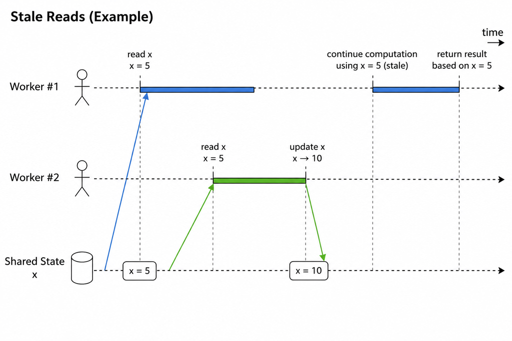

- **Lost update**
  - initial state: `x = 0`
  - worker #1 reads `x = 0`, computes `x + 1`
  - worker #2 reads `x = 0`, computes `x + 1`
  - worker #1 writes `x = 1`
  - worker #2 writes `x = 1`
  - final state: `x = 1` (**one update lost**)

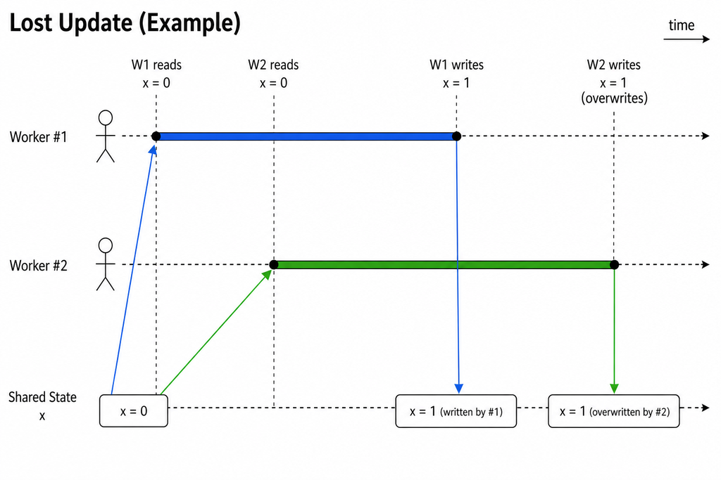

- **Race conditions**
  - initial state: `x = 1`
  - worker #1 reads `x`, computes `x * 2`
  - worker #2 reads `x`, computes `x + 3`
  - depending on execution order:
    - worker #1 → worker #2:
      - worker #1: `x = 1 → 2`
      - worker #2 reads updated `x = 2`, writes `x = 5`
    - worker #2 → worker #1:
      - worker #2: `x = 1 → 4`
      - worker #1 reads updated `x = 4`, writes `x = 8`
  - final state is `5` or `8` → **depends on timing (non-deterministic)**

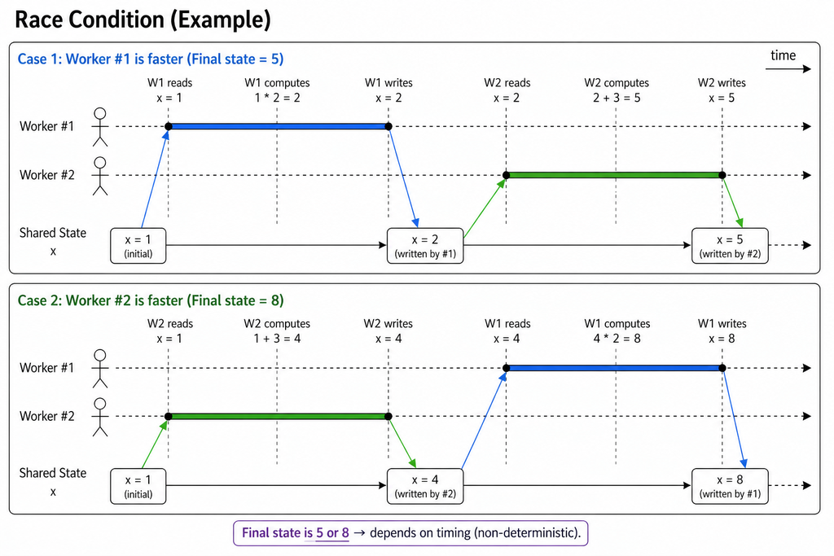

- ...
- [(Martin Kleppmann's lectures)](https://www.youtube.com/playlist?list=PLeKd45zvjcDFUEv_ohr_HdUFe97RItdiB)

### Ray's solution:

- Actors **own the state** (no shared mutable state across workers)
- Only the actor can **mutate its own state** (single writer)
- Tasks submit method calls to the actor
- A default synchronous actor executes one method at a time in its dedicated process.
- Calls from one submitter normally retain submission order. Different submitters have no deterministic global call order, so state transitions can depend on timing.

The diagram shows serialized execution, not a guaranteed cross-submitter order.

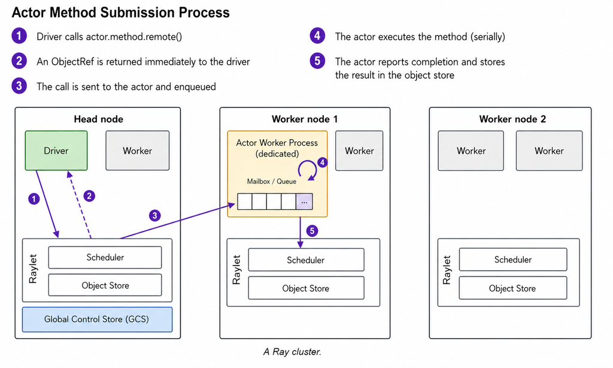

```python
@ray.remote
class Sleeper:
    def work(self, label, delay_s):
        start = time.perf_counter()
        print(f"{label}: start")
        time.sleep(delay_s)
        elapsed = time.perf_counter() - start
        print(f"{label}: finished after {elapsed:.2f}s")
        return label
```

```python
sleeper = Sleeper.remote()

start = time.perf_counter()
refs = [
    sleeper.work.remote("job-1", 2.0),
    sleeper.work.remote("job-2", 2.0),
]
out = ray.get(refs)
elapsed = time.perf_counter() - start

time.sleep(0.1)
print("Output :", out)
print(f"Elapsed: {elapsed:.2f} seconds")
```

```
(Sleeper pid=304972) job-1: start
(Sleeper pid=304972) job-1: finished after 2.00s
(Sleeper pid=304972) job-2: start
(Sleeper pid=304972) job-2: finished after 2.00s
Output : ['job-1', 'job-2']
Elapsed: 4.08 seconds
```

Serial execution `=>` total time is about **4 seconds**, not 2.

## 5. Different actors: independent state, parallel execution

```python
@ray.remote
class Sleeper:
    def __init__(self):
        self.count = 0

    def work(self, name, t):
        self.count += 1
        print(f"[{name}] start")
        time.sleep(t)
        print(f"[{name}] end")
        return self.count


sleeper_a = Sleeper.remote()
sleeper_b = Sleeper.remote()

start = time.perf_counter()
refs = [
    sleeper_a.work.remote("actor-A", 2.0),
    sleeper_b.work.remote("actor-B", 2.0),
]
out = ray.get(refs)
elapsed = time.perf_counter() - start

time.sleep(0.1)
print("Returned:", out)
print(f"Elapsed: {elapsed:.2f} seconds")
```

```
(Sleeper pid=222736) [actor-B] start
(Sleeper pid=298508) [actor-A] start
(Sleeper pid=222736) [actor-B] end
(Sleeper pid=298508) [actor-A] end
Returned: [1, 1]
Elapsed: 2.10 seconds
```

- Methods on **different** actors run in parallel.
- Each actor has an independent `count` state.

## 6. Actor use case: expensive initialization

Loading a ML model is expensive (I/O, deserialization, warmup), but inference is cheap.

Actors let us **load once and reuse**:

- model is initialized once per actor
- repeated `predict` calls reuse the same in-memory model
- avoids reloading the model on every call

```python
@ray.remote
class ToyModelServer:
    def __init__(self):
        print("Loading model once...")
        time.sleep(2.0)
        self.bias = 0.5

    def predict(self, x):
        return x + self.bias
```

```python
start = time.perf_counter()
server = ToyModelServer.remote()
created = time.perf_counter() - start

print(f"Actor creation call returned in {created:.2f} seconds")

start = time.perf_counter()
preds = ray.get([server.predict.remote(x) for x in [1.0, 2.0, 3.0]])
elapsed = time.perf_counter() - start

print("Predictions:", preds)
print(f"Time to first predictions: {elapsed:.2f} seconds")
```

```
Actor creation call returned in 0.01 seconds
(ToyModelServer pid=323752) Loading model once...
Predictions: [1.5, 2.5, 3.5]
Time to first predictions: 2.07 seconds
```

Actor creation returns quickly because:

1. `.remote()` submits the actor creation request and immediately returns a handle.
2. Ray schedules the actor on a node.
3. The actor process starts and runs `__init__`.
4. Actor method calls will queue until initialization completes.

The model-loading cost is paid **once per actor**.

After that, later method calls reuse the actor's state (fast predictions).

```python
start = time.perf_counter()
preds = ray.get([server.predict.remote(x) for x in [1.0, 2.0, 3.0]])
elapsed = time.perf_counter() - start

print("Predictions:", preds)
print(f"Elapsed: {elapsed:.2f} seconds")
```

```
Predictions: [1.5, 2.5, 3.5]
Elapsed: 0.00 seconds
```

## 7. Passing actor handles

An actor handle is a reference to one live actor. You can pass that handle into a task just like you pass normal arguments.

The receiving task does **not** receive a copy of the actor or its internal state. It receives a way to submit methods to the same actor instance.

A common pattern is:

1. The driver creates a long-lived actor that owns mutable state.
2. Stateless tasks receive the actor handle as an argument.
3. Those tasks call actor methods when they need to update or query shared state.
4. The actor remains the single place where the state is mutated.

In this example, two tasks receive the same `Counter` handle and both submit increments to it. Each task sleeps for a random amount of time before submitting its next actor call, which creates a race in the **submission order**. The tasks may run at the same time, but all `increment` calls are serialized by the actor.

```python
@ray.remote
def submit_increments(counter_handle, producer_name, num_increments, max_submit_delay_s=0.25):

    refs = []

    for _ in range(num_increments):
        time.sleep(random.uniform(0.0, max_submit_delay_s))
        refs.append(counter_handle.increment.remote())

    values = ray.get(refs)

    return {
        "producer": producer_name,
        "increments_seen": values,
    }
```

```python
shared_counter = Counter.remote()

task_refs = [
    submit_increments.remote(shared_counter, "task-A", 5),
    submit_increments.remote(shared_counter, "task-B", 5),
]

reports = ray.get(task_refs)
final_value = ray.get(shared_counter.get_value.remote())

for report in reports:
    print(f"{report['producer']} saw {report['increments_seen']}")

print("Final actor state:", final_value)
```

```
task-A saw [1, 2, 3, 5, 7]
task-B saw [4, 6, 8, 9, 10]
Final actor state: 10
```

The important idea is that the handle is a **capability**, not the actor's data. Passing it around does not move the actor, duplicate the actor, or expose `self.value` directly. It gives another task permission to enqueue work on that actor.

There are two levels of asynchronous work in the example:

1. The driver submits two `submit_increments(...)` tasks.
2. Each task submits several `increment(...)` actor method calls.

The random sleep makes the intermediate values printed by each task vary from run to run. This is a submission-order race, not a lost-update race. The final actor state should still be `10`, because every increment went through the same `Counter` actor.

## 8. Summary

1. An **actor** is a long-lived remote class instance.
2. Actor methods are invoked with `.remote(...)`.
3. Actor methods return `ObjectRef`s, just like tasks.
4. Methods on the **same** actor run **serially**.
5. Methods on **different** actors can run in parallel.
6. Actors are useful when you need **state**, **caching**, or **expensive initialization**.

## 9. Exercises

1. Use the `Counter` class to create an example where stale reads occur.
   - Hint: read state, then delay before using it.
2. Modify `Counter` to introduce **lost updates**:
   - implement `increment(x)` as `state = x + 1`
   - call it with stale values
3. Modify `ToyModelServer` so that it also stores:
   - `num_requests`
   - `last_input`

   Then expose a `stats(...)` method.
4. Create **four** `ToyModelServer` actors and distribute requests across them.
   - Compare one actor vs four actors.
   - What changes in latency and throughput?
   - Hint: route each request to a random actor (e.g. `np.random.randint(4)`)

```python
ray.shutdown()
```